# Yu_EEOB5460_Python_Assignment

### Note: Besides referencing the course slides, I used these websites for help throughout this assignment.

- https://biopython.org/
- https://www.w3schools.com/python/pandas/
- https://pandas.pydata.org/
- https://seaborn.pydata.org/

# Python Translate Script

### Here's the start of our Python script. Thanks for completing it for me! - Dr. X

### IMPORTANT: install BioPython so that this will work

```python
from Bio import SeqIO
from Bio.Data import CodonTable
import pandas as pd
```

# FUNCTIONS

## 1.

Dr. X: this gets sequences Please properly document this function in the Jupyter notebook Your descriptions of all functions should contain information about what the function does, as well as information about the return types and arguments.

Valerie (me): Explanation for each code line is commented below the code. In sum, this function reads a FASTA file and returns a dictionary of the sequences indexed by species name. The input is `fasta_fn` and the return is a dictionary. In the dictionary, each species name has a value (corresponding sequence).

```python
def get_sequences_from_file(fasta_fn):
    # This function reads a FASTA file, `fasta_fn`.
    sequence_data_dict = {}
    # Here, it is creating an empty dictionary.
    for record in SeqIO.parse(fasta_fn, "fasta"):
    # For every `record`, aka sequence entry, SeqIO (Biopython Library) reads through each entry in the `fasta_fn` FASTA file.
        description = record.description.split()
        # Splits the text string description in the record into a list of smaller substrings.
        species_name = description[1] + " " + description[2]
        # Makes `species_name` the second and third word (since we have zero-based index in Python).
        # There will be a space between I'm assuming the genus and species
        sequence_data_dict[species_name] = record.seq
        # `species_name` is stored into the dictionary Dr. X created, with `record.seq` being the sequence values.
    return(sequence_data_dict)
    # Returns the now filled dictionary.
```

## 2. YOUR STRING-TRANSLATE FUNCTION

Write a function that translates sequences. All sequences start at codon position 1. Complete a function that translates using a loop over the string of nucleotides. Here is some pseudo-code and suggestions. Feel free to change the function and variable names

Valerie: Like above, my explanation is below the code. I replaced the pseudo-code.

This function takes the sequence `string_nucleotides` and reads each group of three nucleotides (codons). It then translates each codon into amino acids using the Vertebrate Mitochondrial Codon Table. Any incomplete codons at the end are skipped and the loop is stopped if it runs into a stop codon. Returns an amino acid sequence as a string.

```python
def translate_function(string_nucleotides):
    mito_table = CodonTable.unambiguous_dna_by_name["Vertebrate Mitochondrial"]
    # This should work using BioPython and I will check what this returns to make sure.

    aa_seq_string = ""
    # I am making a for-loop. Following Dr. X's example, I need to create an empty string for my amino acids.

    for i in range(0, len(string_nucleotides), 3):
    # This is the for-loop. I use `range(start at 0, stop at end aka the length of sequence, step is 3):`
    # Codons are made of 3 nucleotides.

        codon = str(string_nucleotides[i:i+3])
        # Unlike in R, Python has zero-based indexing and cuts before end, so I use i+3 to include all 3 nucleotides.

        if len(codon) < 3:
            continue
        # This is saying "if the length codon is less than 3, aka not a full codon at the end, skip it."

        if codon in mito_table.stop_codons:
            break
        # This is saying "if the codon is one of the stop codons, break", with break = exit loop

        amino_acid = mito_table.forward_table[codon]
        # mito_table.forward_table[codon] allows us to retrieve the amino acid
        aa_seq_string = aa_seq_string + amino_acid
        # then I add the amino acid onto the protein sequence `aa_seq_string`

    return aa_seq_string

# mito_table = CodonTable.unambiguous_dna_by_name["Vertebrate Mitochondrial"]
# print(mito_table)
# print(mito_table.stop_codons)
# print(mito_table.forward_table)
```

## 3. YOUR ALTERNATIVE FUNCTION

Is there a better way to write the translation function? (Hint: yes there is)

Perhaps using available BioPython library utilities? Please also write this function.

Valerie: `Getting Started Tips` says use .translate() for amino acid sequences. That's in the BioPython library. `.translate()` will "turn a nucleotide sequence into a protein sequence by creating a new Seq object". This means no for-loop.

```python
# I need to tell it which table to reference. It also has a `to_stop` argument for stop codons.
def biopython_translate_function(string_nucleotides):
    biopython_aa_sequence = string_nucleotides.translate(table = "Vertebrate Mitochondrial", to_stop = True)
    # I set it to true since I don't want the stop symbols in my string.
    return str(biopython_aa_sequence)
```

## 4. YOUR COUNT AA ANALYSIS FUNCTION

Write a function that calculates the molecular weight of each amino acid sequence. For this, you can use some BioPython functions. I think you can use the ProtParam module.

For more info, check this out: http://biopython.org/wiki/ProtParam

So you should import the following before defining your function:

```python
from Bio.SeqUtils.ProtParam import ProteinAnalysis

def compute_molecular_weight(aa_seq):
    aa_seq = str(aa_seq)
    # I think the ProtParam functions may require aa_seq to be a string.
    analysed_seq = ProteinAnalysis(aa_seq)
    # Runs the ProteinAnalysis() function on aa_seq.
    return analysed_seq.molecular_weight()
    # Returns the molecular weight.

# It may not work if the amino acid sequence has stop codons. I believe this shouldn't be an issue.
# I excluded stop codons earlier with `if codon in mito_table.stop_codons: break` in the original.
# Setting `to_stop = TRUE` in the alternative BioPython function also excludes stop codons/stopsymbol.
```

## 5. YOUR GC CONTENT ANALYSIS FUNCTION

Write a function that calculates the GC-content (proportion of "G" and "C") of each DNA sequence and returns this value.

```python
def compute_GC_content(DNA_seq):
    DNA_seq = str(DNA_seq)
    # Just incase it's not a string.
    G_count = DNA_seq.count("G")
    C_count = DNA_seq.count("C")
    # These give me separate variable for G and C.
    GC_content = (G_count + C_count) / len(DNA_seq)
    # We want proportion of G and C to total amount of nucleotides.
    return GC_content
```

# MAIN

```python
cytb_seqs = get_sequences_from_file("penguins_cytb.fasta")

penguins_df = pd.read_csv("penguins_mass.csv") # Includes only data for body mass
species_list = list(penguins_df.species)
```

## 6.

Add two new columns to the penguin DataFrame: (1) molecular weight and (2) GC content. Set the value to 'NaN' to indicate that these cells are currently empty.

```python
# I used penguins_df.head() to check before and saw only `species` and `mass` headers.
penguins_df["molecular weight"] = float("NaN")
penguins_df["GC content"] = float("NaN")
penguins_df.head()
# Now I see `molecular weight` and `GC content`. Both have `NaN` in each cell.
```

|  | species | mass | molecular weight | GC content |
| --- | --- | --- | --- | --- |
| 0 | Aptenodytes forsteri | 28.00 | NaN | NaN |
| 1 | Aptenodytes patagonicus | 13.40 | NaN | NaN |
| 2 | Eudyptes chrysocome | 2.80 | NaN | NaN |
| 3 | Eudyptes chrysolophus | 4.50 | NaN | NaN |
| 4 | Eudyptes sclateri | 4.25 | NaN | NaN |

## 7.

### Write a for-loop that translates each sequence and also gets molecular weight and computes the GC content of each translated sequence and adds those data to DataFrame

```python
for species_name, DNA_seq in cytb_seqs.items():
    aa_seq = biopython_translate_function(DNA_seq)
    # Using alternative function 3 to translate sequence.
    molecular_weight = compute_molecular_weight(aa_seq)
    # Using function 4 to calculate molecular weight of each amino acid sequence.
    GC_content = compute_GC_content(DNA_seq)
    # Using function 5 to find GC content.

    penguins_df.loc[penguins_df["species"] == species_name, "molecular weight"] = molecular_weight
    penguins_df.loc[penguins_df["species"] == species_name, "GC content"] = GC_content
    # To fill in empty cells in DF, I use `.loc` to select column names.

penguins_df.head()
```

|  | species | mass | molecular weight | GC content |
| --- | --- | --- | --- | --- |
| 0 | Aptenodytes forsteri | 28.00 | 42459.6021 | 0.483815 |
| 1 | Aptenodytes patagonicus | 13.40 | 42563.7067 | 0.496938 |
| 2 | Eudyptes chrysocome | 2.80 | 42475.5753 | 0.511811 |
| 3 | Eudyptes chrysolophus | 4.50 | 42445.5493 | 0.509186 |
| 4 | Eudyptes sclateri | 4.25 | 42475.5753 | 0.508311 |

## 8.

### Plot a bar-chart of the mass with the x-axes labeled with species names.

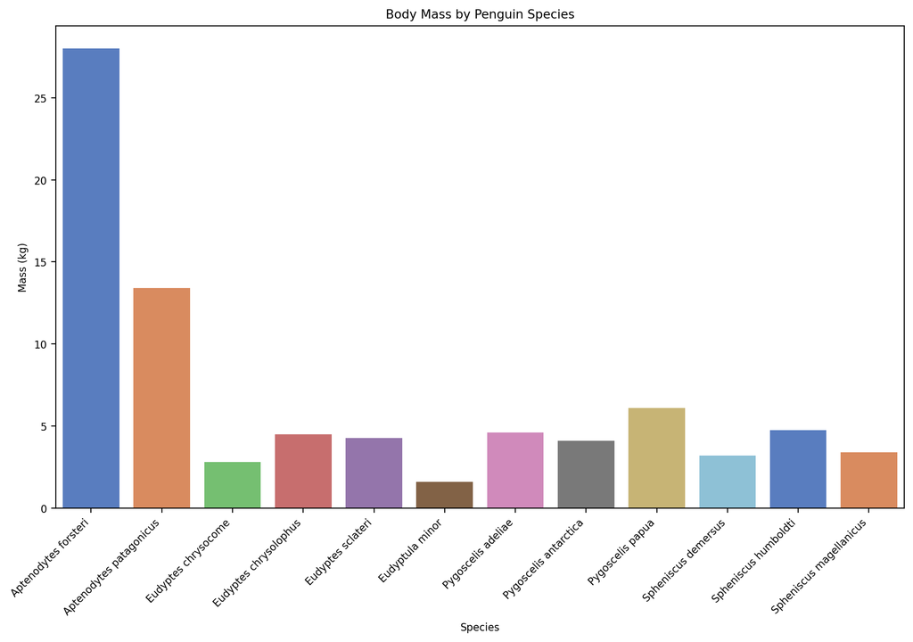

```python
import seaborn as sns
import matplotlib.pyplot as plt

plt.rcParams['figure.dpi'] = 200
plt.rcParams['figure.figsize'] = 10,7
plt.rcParams.update({'font.size': 8})
# Directly from course slides. I changed some default settings to make the plot look better.

graph_8 = sns.barplot(data = penguins_df, x = "species", y = "mass", hue = "species", palette = "muted")
graph_8.set_xlabel("Species")
graph_8.set_ylabel("Mass (kg)")
graph_8.set_title("Body Mass by Penguin Species")
plt.xticks(rotation = 45, ha = "right")
plt.tight_layout()
# I used seaborn.pydata.org for help.
```

### *Q1* What is the smallest penguin species?

Eudyptula minor!!

### *Q2* What is the geographical range of this species?

Eudyptula minor is endemic to the southern coasts of Australia and around New Zealand.

Photo display help from : https://stackoverflow.com/questions/11854847/how-can-i-display-an-image-from-a-file-in-jupyter-notebook

Information from IUCN Red List : https://www.iucnredlist.org/species/22697805/202126091

[figure not shown]

```python
from IPython.display import Image
Image(filename = 'Eudyptula_minor_Geographic_Range.png')
```

## 9.

### Plot a visualization of the molecular weight (y-axis) as a function of GC-content (x-axis).

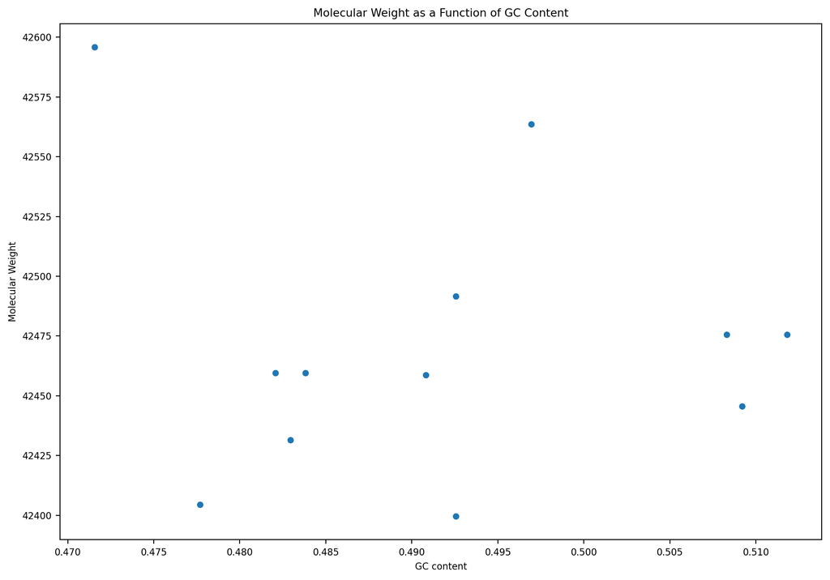

```python
import seaborn as sns
import matplotlib.pyplot as plt

plt.rcParams['figure.dpi'] = 200
plt.rcParams['figure.figsize'] = 10,7
plt.rcParams.update({'font.size': 8})
# Directly from course slides. I changed some default settings to make the plot look better.

graph_9 = sns.scatterplot(data = penguins_df, x = "GC content", y = "molecular weight")
graph_9.set_xlabel("GC content")
graph_9.set_ylabel("Molecular Weight")
graph_9.set_title("Molecular Weight as a Function of GC Content")
plt.tight_layout()
# I used seaborn.pydata.org for help.
```

## 10

### Save the new DataFrame to a file called "penguins_mass_cytb.csv"

```python
penguins_df.to_csv('penguins_mass_cytb.csv', index=False)
```